# HW4 (Data analysis in astronomy)

# You can explore the parameters

### Again produce the plot with the two curves.

### [15 points]

```
number, accuracy_train, accuracy_test
1 0.39 0.39
2 0.66 0.66
3 0.78 0.77
4 0.89 0.87
5 0.93 0.94
6 0.95 0.95
7 0.97 0.97
8 0.98 0.97
9 0.99 0.98
10 0.99 0.99
11 0.99 0.99
12 0.99 0.99
13 0.99 0.99
14 1.0 0.99
```

[output cut: 16 more lines]

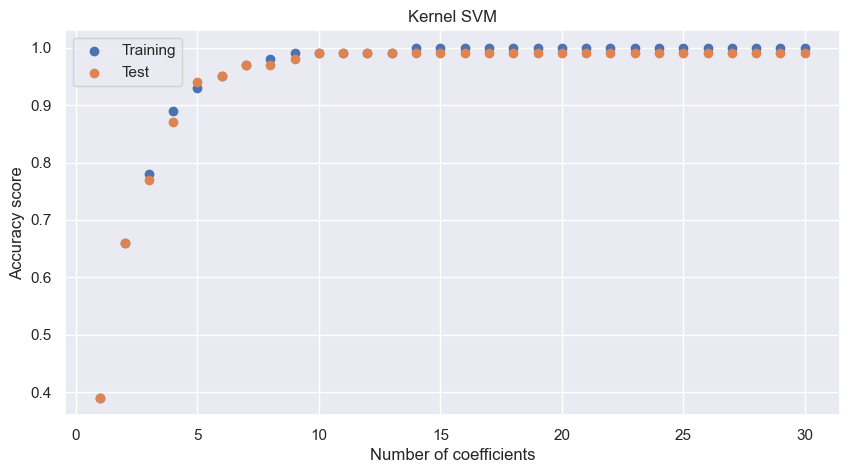

```python
### 5. Use KERNEL SVM and do the same analysis to obtain the accuracy score of the training dataset and the test data as a function of number of coefficients used in the training.
# You can explore the parameters
### Again produce the plot with the two curves.
### [15 points]

accuracy = []
accuracy_t = []
print("number, accuracy_train, accuracy_test")
for i in range(1, 31):
    svc = ss.SVC(kernel='rbf')  # Using RBF
    svc.fit(coeff[:, :i], y_train)
    number_pred = svc.predict(coeff[:, :i])
    number_pred_t = svc.predict(coeff_t[:, :i])

    acc = round(sm.accuracy_score(y_train, number_pred), 2)
    acc_t = round(sm.accuracy_score(y_test, number_pred_t), 2)
    print(i, acc, acc_t)

    accuracy.append(acc)
    accuracy_t.append(acc_t)

plt.figure(figsize=(10, 5))
plt.scatter(range(1, 31), accuracy)
plt.scatter(range(1, 31), accuracy_t)
plt.xlabel('Number of coefficients')
plt.ylabel('Accuracy score')
plt.legend(['Training', 'Test'])
plt.title('Kernel SVM')
plt.show()
```

### 6. What is the best accuracy score you can get for the test data set with SVM (both linear and Kernel)?

### [5 points]

```python
#### What is the best accuracy score you can get for the test data set with SVM (both linear and Kernel)?
### [5 points]

# for linear SVM, the best accuracy score is around 0.97
# for kernel SVM, the best accuracy score is also around 0.99
```

### Finally, We use random forest to do the classification.

### 7. Use Random forest and do the same analysis to obtain the accuracy score of the training dataset and the test data as a function of number of coefficients used in the training.

### You need to also adjust the max_depth parameter and find the depth with best performance.

# You can explore the parameters

### (a) produce a plot with x-axis (max depth) and y-axis (number of coefficients) with colors indicating the accuracy score and

### find the best accuracy score for each number of coefficients.

### (b) Plot the number of coefficients vs best accuracy score for training and test dataset.

### [15 points]

[figure not shown]

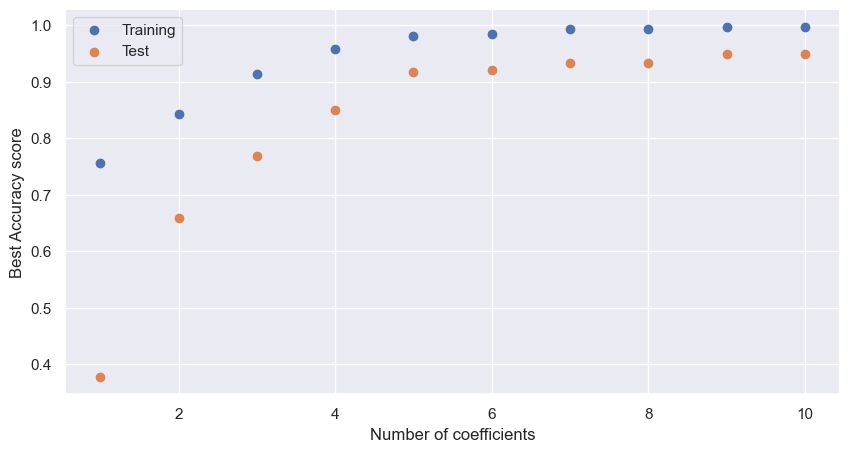

```python
from sklearn.ensemble import RandomForestClassifier
import numpy as np

### Finally, We use random forest to do the classification.
### 7. Use Random forest and do the same analysis to obtain the accuracy score of
# the training dataset and the test data as a function of number of coefficients used in the training.


import matplotlib.pyplot as plt

max_depths = range(1, 11)
num_coefficients = range(1, 11)
accuracy_scores = np.zeros((len(max_depths), len(num_coefficients)))
accuracy_scores_test = np.zeros((len(max_depths), len(num_coefficients)))

for i, max_depth in enumerate(max_depths):
    for j, num_coeff in enumerate(num_coefficients):
        rf = RandomForestClassifier(max_depth=max_depth, random_state=42)
        rf.fit(coeff[:, :num_coeff], y_train)
        accuracy_scores[i, j] = sm.accuracy_score(y_train, rf.predict(coeff[:, :num_coeff]))

        accuracy_scores_test[i, j] = sm.accuracy_score(y_test, rf.predict(coeff_t[:, :num_coeff]))



plt.figure(figsize=(12, 6))
plt.subplot(1, 2, 1)
plt.imshow(accuracy_scores, interpolation='nearest', cmap='viridis', aspect='auto')
plt.colorbar()
plt.xticks(np.arange(len(max_depths)), max_depths)
plt.yticks(np.arange(len(num_coefficients)), num_coefficients)
plt.ylabel('Number of coefficients')
plt.xlabel('Max depth')
plt.title('Training Accuracy')

plt.subplot(1, 2, 2)
plt.imshow(accuracy_scores_test, interpolation='nearest', cmap='viridis', aspect='auto')
plt.colorbar()
plt.xticks(np.arange(len(max_depths)), max_depths)
plt.yticks(np.arange(len(num_coefficients)), num_coefficients)
plt.ylabel('Number of coefficients')
plt.xlabel('Max depth')
plt.title('Test Accuracy')

plt.tight_layout()
plt.show()

# (b) Plot the number of coefficients vs best accuracy score for training and test dataset
best_accuracy_train = np.max(accuracy_scores, axis=0)
best_accuracy_test = np.max(accuracy_scores_test, axis=0)


plt.figure(figsize=(10, 5))
plt.scatter(num_coefficients, best_accuracy_train, label='Training')
plt.scatter(num_coefficients, best_accuracy_test, label='Test')
plt.xlabel('Number of coefficients')
plt.ylabel('Best Accuracy score')
plt.legend()
plt.show()
```

### 8. (a.) Print the feature importance, and tell me which feature is the most important.

### (b.) What is the best accuracy score you can get for the test data set with Random forest method.

### [5 points]

```
The best accuracy score for training dataset is:  [0.75649592 0.84187082 0.9138827  0.95768374 0.97995546 0.9844098
 0.99331849 0.99331849 0.99703044 0.99628805]
The best accuracy score for test dataset is:  [0.37777778 0.65777778 0.76888889 0.84888889 0.91777778 0.92
 0.93333333 0.93333333 0.94888889 0.94888889]
```

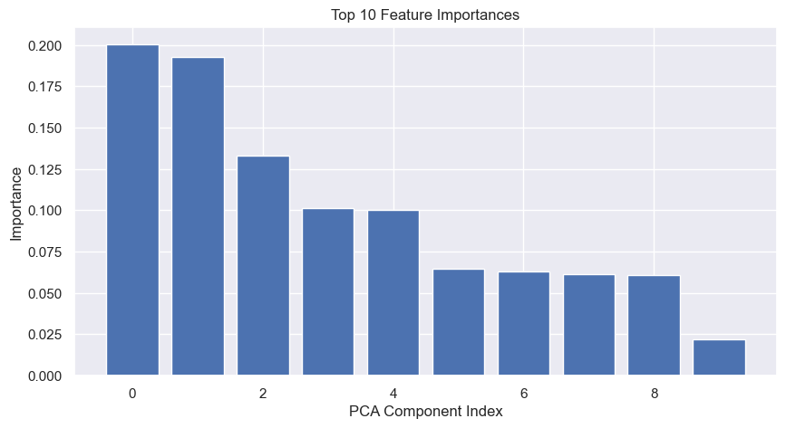

```
The most important features in PCA compoments :
[0 1 2 3 4 5 8 7 6 9]
```

```python
print("The best accuracy score for training dataset is: ", best_accuracy_train)
print("The best accuracy score for test dataset is: ", best_accuracy_test)

# find the number of coefficients and maxdepth that gives the best accuracy score
best_num_coeff_train = num_coefficients[np.argmax(best_accuracy_train)]
best_num_coeff_test = num_coefficients[np.argmax(best_accuracy_test)]
best_max_depth_train = max_depths[np.argmax(best_accuracy_train)]
best_max_depth_test = max_depths[np.argmax(best_accuracy_test)]


importances = rf.feature_importances_
indices = np.argsort(importances)[::-1]
plt.figure(figsize=(10, 5))
plt.bar(range(10), importances[indices[:10]], align="center")
plt.xlabel("PCA Component Index")
plt.ylabel("Importance")
plt.title("Top 10 Feature Importances")
plt.show()

# the most important features

print("The most important features in PCA compoments :")

print(np.argsort(rf.feature_importances_)[::-1][:10])
```

### 9. Compare the best accuracy scores from logistic regression, SVM, random forest and tell me

### which model works the best?

### [5 points]

```python
#  Compare the best accuracy scores from logistic regression, SVM, random forest and tell me
### which model works the best?

# The best accuracy score for logistic regression is ~0.97
# The best accuracy score for linear SVM is ~0.97
# The best accuracy score for kernel SVM is ~0.99
# The best accuracy score for random forest is ~0.95

# Kernel SVM works the best among the models.
```